# Statistical Inference Project 1: Part1 Exponential Distribution Versus Central Limit Theorem

Frank Minjarez

March 13, 2017

Code Here: https://github.com/frankminjarez/StatisticalInference.git

## Overview

In this project we investigate the exponential distribution in R and compare it with the Central Limit Theorem. The exponential distribution is simulated in R with rexp(n, lambda) where lambda is the rate parameter. The mean of exponential distribution is 1/lambda and the standard deviation is also 1/lambda. We set lambda = 0.2 for all of the simulations. We investigate the distribution of averages of 40 exponentials using one thousand simulations.

We’ll illustrate via simulation and associated explanatory text the properties of the distribution of the mean of 40 exponentials.

1. Show the sample mean and compare it to the theoretical mean of the distribution.
2. Show how variable the sample is (via variance) and compare it to the theoretical variance of the distribution.
3. Show that the distribution is approximately normal.

## Simulations

Run 1000 simulations finding the mean of 40 expotential distribution observations with lambda equal to 0.2. Use the simulations to create a sample data set for comparison to the theoretical mean of the distribution.

```r
# lambda is 0.2
lambda = 0.2
# 40 observations
n = 40
# 1000 simulations
nsims = 1:1000
# set a seed
set.seed(8080)
# create sim_data
sim_data <- data.frame(value = sapply(nsims, function(x) {mean(rexp(n, lambda))}))
```

### Sample Mean Versus Theoretical Mean

The sample mean is nearly identical to the theoretical mean.

```r
sample_mean <- mean(sim_data$value)
sample_mean
```

```
## [1] 5.027805
```

```r
theoretical_mean <- 1 / lambda
theoretical_mean
```

```
## [1] 5
```

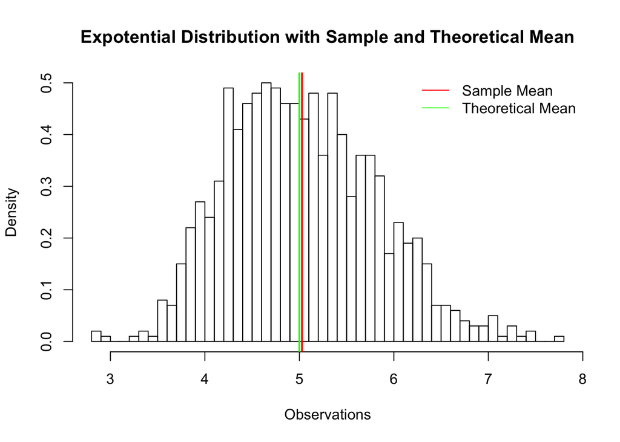

```r
hist(sim_data$value,
     breaks = 50,
     prob = TRUE,
     main = "Expotential Distribution with Sample and Theoretical Mean",
     xlab = "Observations")

abline(v = theoretical_mean,
       col = "green",
       lwd = 2)

abline(v = sample_mean,
       col = "red",
       lwd = 2)

legend("topright",
       c("Sample Mean", "Theoretical Mean"),
       bty = "n",
       lty = c(1, 1),
       col = c("red", "green"))
```

## Sample Variance vs Theoretical Variance of the Distribution

As you can see below, the sample variance is nearly identical to the theoretical variance.

```r
simulation_var <- var(sim_data$value)
simulation_var
```

```
## [1] 0.6149259
```

```r
theoretical_var <- ((1/lambda)^2)/40
theoretical_var
```

```
## [1] 0.625
```

## Show that the Distribution is Approximately Normal

The simulation samples follow normal distribution.

The figure below shows the density of the simulations values versus the normal distribution. As you can see the simulation distribution and the theoretical normal distributions are very close to matching.

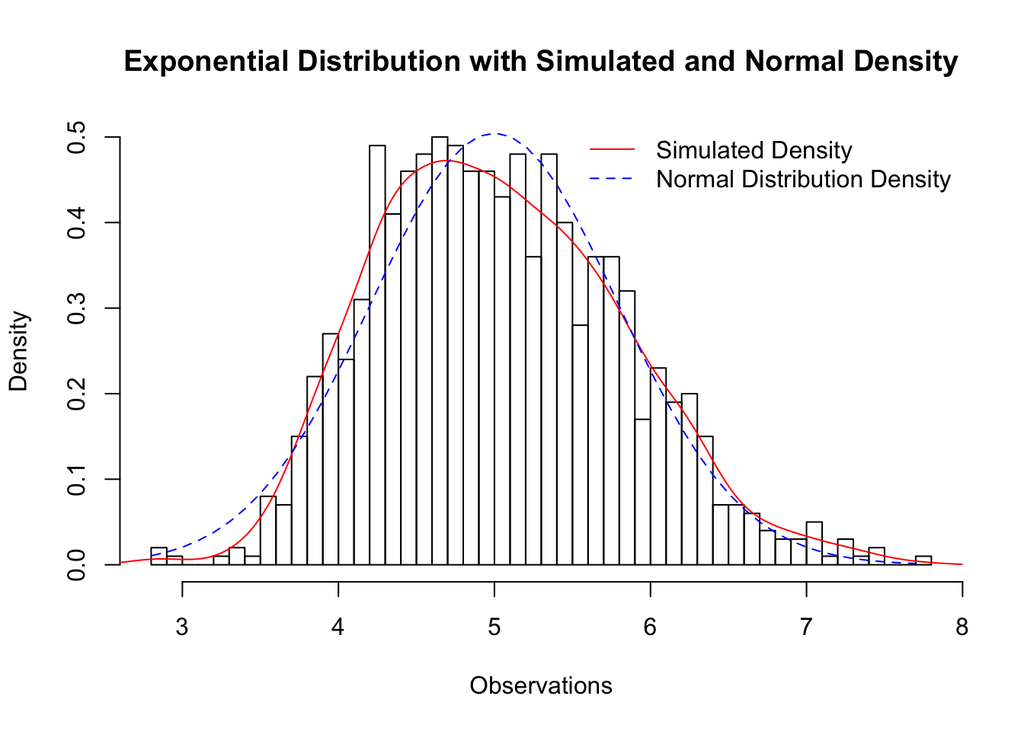

```r
hist(sim_data$value,
     breaks = 50,
     prob = TRUE,
     main = "Exponential Distribution with Simulated and Normal Density",
     xlab = "Observations")

## Sample density
lines(density(sim_data$value), col="red")

## Theoretical normal density
xnorm <- seq(min(sim_data$value), max(sim_data$value), length = 50)
ynorm <- dnorm(xnorm, mean = 1/lambda, sd = (1/lambda/sqrt(40)))
lines(xnorm, ynorm, pch = 22, col = "blue", lty = 2)

legend("topright", c("Simulated Density", "Normal Distribution Density"),
       bty = "n", lty = c(1,2), col = c("red", "blue"))
```

The theoretical quantiles match closely with the simulated quantiles.

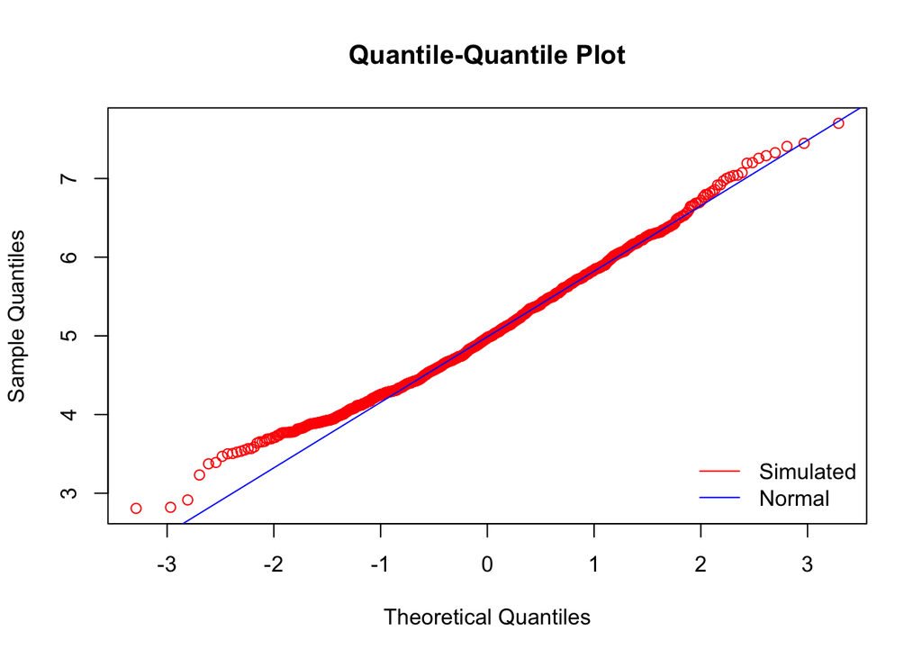

```r
qqnorm(sim_data$value,
       main ="Quantile-Quantile Plot",col="red")
qqline(sim_data$value,
       col = "blue")
legend("bottomright", c("Simulated", "Normal"),
       bty = "n", lty = c(1,1), col = c("red", "blue"))
```

Finally, we compare 95% confidence intervals. We see that they nearly match too.

```r
simulation_interval <- round (mean(sim_data$value) + c(-1,1)*1.96*sd(sim_data$value)/sqrt(n),3)
theoretical_interval <- theoretical_mean + c(-1,1)*1.96*sqrt(theoretical_var)/sqrt(n);
simulation_interval
```

```
## [1] 4.785 5.271
```

```r
theoretical_interval
```

```
## [1] 4.755 5.245
```